# Lesonia trabeculata data

SUBELAB

26 de agosto de 2022

### 1. IFOP information

This project evaluate the kelp forest state in TURF sites (also called AMERB in Spanish) evaluating kelp density, kelp morphology, herbivores and fish communities.

#### 1.1. Sites & georeferences by year

```r
coord <- read.csv("coordenadas.csv")
kable(coord) %>%
  kable_styling(bootstrap_options=c("striped", "hover", "condensed"),
                full_width = F)
```

| Year | Number_Region | Site | Management | Latitude | Longitude |
| --- | --- | --- | --- | --- | --- |
| 2018 | V | Quintay A | AMERB | -33.19194 | -71.70034 |
| 2018 | V | Quintay B | AMERB | -33.20387 | -71.70390 |
| 2018 | XVI | Cobquecura | AMERB | -36.15519 | -72.82356 |
| 2018 | V | Las Cruces | AMERB | -33.50403 | -71.63217 |
| 2018 | V | Ventanas | AMERB | -32.72171 | -71.50679 |
| 2018 | IV | Los Vilos | AMERB | -31.93410 | -71.51777 |
| 2018 | III | Cha<96>aral de Aceituno | AMERB | -29.16419 | -71.49692 |
| 2018 | III | Carrizal Bajo | AMERB | -28.04086 | -71.15189 |
| 2018 | III | Reserva Cha<96>aral de Aceituno | Reserva | -29.04175 | -71.59110 |
| 2018 | II | Punta El Yeso | AMERB | -23.41667 | -70.60014 |
| 2019 | V | Ventanas | AMERB | -32.72171 | -71.50679 |
| 2019 | V | Quintay A | AMERB | -33.19194 | -71.70034 |
| 2019 | V | Quintay B | AMERB | -33.20387 | -71.70390 |
| 2019 | VIII | Cobquecura | AMERB | -36.15519 | -72.82356 |
| 2020 | III | Cha<96>aral de Aceituno | AMERB | -29.16419 | -71.49692 |
| 2020 | III | Cha<96>aral de Aceituno | OA | NA | NA |
| 2020 | III | Reserva Cha<96>aral de Aceituno | Reserve | -29.04175 | -71.59110 |
| 2020 | IV | Los Vilos | AMERB | -31.93410 | -71.51777 |
| 2020 | V | Quintay B | AMERB | -33.20387 | -71.70390 |
| 2020 | XVI | Cobquecura | AMERB | -36.15519 | -72.82356 |
| 2022 | I | Pisagua | AMERB | -19.56843 | -70.20759 |
| 2022 | II | Punta Arenas | AMERB | -21.67191 | -70.15316 |
| 2022 | II | Punta El Yeso | AMERB | -23.41667 | -70.60014 |
| 2022 | III | Carrizal Bajo | AMERB | -28.04086 | -71.15189 |
| 2022 | III | Cha<96>aral de Aceituno | AMERB | -29.16419 | -71.49692 |
| 2022 | III | Cha<96>aral de Aceituno | OA | NA | NA |
| 2022 | III | Reserva Cha<96>aral de Aceituno | Reserve | -29.04175 | -71.59110 |
| 2022 | IV | Los Vilos | AMERB | -31.93410 | -71.51777 |

#### 1.2. Methods and databases

- **Ifop_Kelp_Density:** To evaluate kelp density, 7-10 transects of 100x2 meters were monitored in each site. The transect is divided into 10 m stations (n=10), where adult (>10 cm holdfast) and juvenile (<10 cm holdfast) kelp were counted at 1 m on each side (20 m<sup>2</sup>).

```r
IFOP_Kelp_Density <- read_csv("IFOP_Kelp_density.csv", na=c("NaN", "")) %>%
  select (c(1:8,13:18,21)) %>%
  mutate(Date=ymd(paste(Year, Month, Day, sep="-")),
         Site=factor(Site),
         Management=factor(Management),
         Stage=factor(Stage),
         Frondosity=factor(Frondosity)) %>%
  filter(Species=="Lessonia trabeculata")

glimpse(IFOP_Kelp_Density)
```

```
## Rows: 3,713
## Columns: 15
## $ Serie      <dbl> 1, 2, 8, 9, 15, 16, 22, 23, 29, 30, 36, 37, 43, 44, 50, 51,…
## $ Date       <date> 2018-10-28, 2018-10-28, 2018-10-28, 2018-10-28, 2018-10-28…
## $ Day        <dbl> 28, 28, 28, 28, 28, 28, 28, 28, 28, 28, 28, 28, 28, 28, 28,…
## $ Month      <dbl> 10, 10, 10, 10, 10, 10, 10, 10, 10, 10, 10, 10, 10, 10, 10,…
## $ Year       <dbl> 2018, 2018, 2018, 2018, 2018, 2018, 2018, 2018, 2018, 2018,…
## $ Site       <fct> Carrizal Bajo, Carrizal Bajo, Carrizal Bajo, Carrizal Bajo,…
## $ Management <fct> AMERB, AMERB, AMERB, AMERB, AMERB, AMERB, AMERB, AMERB, AME…
## $ Transect   <dbl> 1, 1, 1, 1, 1, 1, 1, 1, 1, 1, 1, 1, 1, 1, 1, 1, 1, 1, 1, 1,…
## $ Station    <dbl> 1, 1, 2, 2, 3, 3, 4, 4, 5, 5, 6, 6, 7, 7, 8, 8, 9, 9, 10, 1…
## $ Depth      <dbl> 15.0, 15.0, NA, NA, NA, NA, NA, NA, NA, NA, NA, NA, 9.3, 9.…
## $ Surface    <dbl> 20, 20, 20, 20, 20, 20, 20, 20, 20, 20, 20, 20, 20, 20, 20,…
## $ Species    <chr> "Lessonia trabeculata", "Lessonia trabeculata", "Lessonia t…
## $ Stage      <fct> Adulto, Juvenil, Adulto, Juvenil, Adulto, Juvenil, Adulto, …
## $ Abundance  <dbl> 18, 2, 12, 2, 25, 29, 29, 10, 38, 3, 22, 1, 69, 2, 53, 2, 4…
## $ Frondosity <fct> A, A, B, B, A, A, A, A, A, A, A, A, A, A, A, A, A, A, A, A,…
```

```r
summary(IFOP_Kelp_Density)
```

```
##      Serie            Date                 Day            Month
##  Min.   :    1   Min.   :2018-05-16   Min.   : 1.00   Min.   : 1.000
##  1st Qu.: 3118   1st Qu.:2018-11-02   1st Qu.: 4.00   1st Qu.: 4.000
##  Median : 6480   Median :2020-03-02   Median :10.00   Median :10.000
##  Mean   : 6218   Mean   :2020-02-20   Mean   :13.42   Mean   : 7.818
##  3rd Qu.: 9236   3rd Qu.:2021-04-16   3rd Qu.:23.00   3rd Qu.:11.000
##  Max.   :12030   Max.   :2022-01-29   Max.   :30.00   Max.   :12.000
##  NA's   :539
##       Year                                Site        Management
##  Min.   :2018   Chanaral de Aceituno C      : 490   AMERB  :3165
##  1st Qu.:2018   Cobquecura                  : 468   OA     : 138
##  Median :2020   Ventanas                    : 414   Reserve: 410
##  Mean   :2020   Quintay B                   : 393
##  3rd Qu.:2021   Quintay A                   : 340
##  Max.   :2022   Reserva Chanaral de Aceituno: 334
##                 (Other)                     :1274
##     Transect         Station           Depth          Surface
##  Min.   : 0.000   Min.   : 1.000   Min.   : 0.40   Min.   : 0.00
##  1st Qu.: 2.000   1st Qu.: 3.000   1st Qu.: 7.60   1st Qu.:20.00
##  Median : 5.000   Median : 5.000   Median :10.30   Median :20.00
##  Mean   : 5.032   Mean   : 5.457   Mean   :10.59   Mean   :20.02
##  3rd Qu.: 7.000   3rd Qu.: 8.000   3rd Qu.:12.90   3rd Qu.:20.00
##  Max.   :17.000   Max.   :10.000   Max.   :27.00   Max.   :60.00
##                   NA's   :1164     NA's   :127     NA's   :1304
##    Species              Stage        Abundance      Frondosity
##  Length:3713        Adulto :1896   Min.   :  0.00   A   :2959
##  Class :character   Juvenil:1817   1st Qu.:  0.00   B   : 398
##  Mode  :character                  Median :  8.00   C   :  74
##                                    Mean   : 15.56   NA's: 282
##                                    3rd Qu.: 24.00
##                                    Max.   :561.00
##
```

- **Ifop_Kelp_Morpho:** In 3 of the transects, the morphology (holdfast size, no. stipes, total length and frondosity) and herbivore density are quantified in 1m<sup>2</sup> quadrants. Between 7-10 quadrants were spread equidistant across the transect.

```r
#Only kelp information
IFOP_Kelp_Morpho <- read_csv("IFOP_Kelp_Morphology.csv", na=c("NaN", "")) %>%
  select(c(1:9,11:13,15:19)) %>%
  mutate(Date=ymd(paste(Year, Month, Day, sep="-")),
         Site=factor(Site),
         Management=factor(Management),
         Frondosity=factor(Frondosity)) %>% # A, B, C, "", NA -- others are 0-4. Is "" == 0?
  filter(Group=="Macroalga", Species=="Lessonia trabeculata")

glimpse(IFOP_Kelp_Morpho)
```

```
## Rows: 2,161
## Columns: 17
## $ Serie      <dbl> 127, 128, 129, 130, 131, 132, 133, 134, 135, 136, 137, 138,…
## $ Date       <date> 2018-05-16, 2018-05-16, 2018-05-16, 2018-05-16, 2018-05-16…
## $ Day        <dbl> 16, 16, 16, 16, 16, 16, 16, 16, 16, 16, 16, 16, 16, 16, 16,…
## $ Month      <dbl> 5, 5, 5, 5, 5, 5, 5, 5, 5, 5, 5, 5, 5, 5, 5, 5, 5, 5, 5, 5,…
## $ Year       <dbl> 2018, 2018, 2018, 2018, 2018, 2018, 2018, 2018, 2018, 2018,…
## $ Site       <fct> Quintay A, Quintay A, Quintay A, Quintay A, Quintay A, Quin…
## $ Management <fct> TURF, TURF, TURF, TURF, TURF, TURF, TURF, TURF, TURF, TURF,…
## $ Transect   <dbl> 5, 5, 5, 5, 5, 5, 5, 5, 5, 5, 5, 5, 5, 5, 5, 5, 5, 5, 5, 5,…
## $ Quadrats   <dbl> 1, 2, 2, 3, 4, 5, 5, 6, 6, 6, 6, 6, 6, 6, 7, 7, 8, 8, 8, 9,…
## $ Depth      <dbl> 20.0, 18.8, 18.8, 19.0, 18.7, 18.8, 18.8, NA, NA, NA, NA, N…
## $ Group      <chr> "Macroalga", "Macroalga", "Macroalga", "Macroalga", "Macroa…
## $ Species    <chr> "Lessonia trabeculata", "Lessonia trabeculata", "Lessonia t…
## $ Abundance  <dbl> 1, 1, 1, 1, 1, 1, 1, 1, 1, 1, 1, 1, 1, 1, 1, 1, 1, 1, 1, 1,…
## $ Holdfast   <dbl> 33, 16, 25, 23, 23, 37, 38, 25, 10, 7, 7, 22, 12, 24, 40, 4…
## $ Stipes     <dbl> 16, 4, 3, 6, 7, 7, 7, 7, 5, 3, 14, 12, 3, 15, 10, 17, 3, 5,…
## $ TL         <dbl> 128, 179, 133, 160, 118, 171, 213, 60, 50, 100, 100, 40, 12…
## $ Frondosity <fct> NA, NA, NA, NA, NA, NA, NA, NA, NA, NA, NA, NA, NA, NA, NA,…
```

```r
summary(IFOP_Kelp_Morpho)
```

```
##      Serie           Date                 Day            Month
##  Min.   : 127   Min.   :2018-05-16   Min.   : 2.00   Min.   : 1.000
##  1st Qu.:1439   1st Qu.:2018-10-28   1st Qu.: 7.00   1st Qu.: 4.000
##  Median :2803   Median :2020-11-02   Median :16.00   Median : 7.000
##  Mean   :2543   Mean   :2020-03-29   Mean   :14.39   Mean   : 7.047
##  3rd Qu.:3488   3rd Qu.:2021-04-17   3rd Qu.:23.00   3rd Qu.:11.000
##  Max.   :4240   Max.   :2022-01-29   Max.   :30.00   Max.   :12.000
##
##       Year                             Site       Management      Transect
##  Min.   :2018   Cobquecura               :246   OA     :  85   Min.   : 1.000
##  1st Qu.:2018   Ventanas                 :236   Reserve: 168   1st Qu.: 2.000
##  Median :2020   Quintay B                :213   TURF   :1908   Median : 5.000
##  Mean   :2020   Punta El Yeso            :185                  Mean   : 4.874
##  3rd Qu.:2021   Cha\x96aral de Aceituno C:179                  3rd Qu.: 7.000
##  Max.   :2022   Los Vilos C              :166                  Max.   :10.000
##                 (Other)                  :936
##     Quadrats          Depth          Group             Species
##  Min.   : 1.000   Min.   : 2.50   Length:2161        Length:2161
##  1st Qu.: 3.000   1st Qu.: 8.80   Class :character   Class :character
##  Median : 4.000   Median :10.70   Mode  :character   Mode  :character
##  Mean   : 4.555   Mean   :10.92
##  3rd Qu.: 6.000   3rd Qu.:12.60
##  Max.   :11.000   Max.   :20.80
##                   NA's   :53
##    Abundance         Holdfast         Stipes             TL        Frondosity
##  Min.   :0.0000   Min.   : 0.00   Min.   : 0.000   Min.   :  0.0   0   :  49
##  1st Qu.:1.0000   1st Qu.:15.00   1st Qu.: 2.000   1st Qu.:104.0   1   :  31
##  Median :1.0000   Median :24.00   Median : 4.000   Median :160.0   2   : 259
##  Mean   :0.9773   Mean   :24.18   Mean   : 5.176   Mean   :152.9   3   :1104
##  3rd Qu.:1.0000   3rd Qu.:33.00   3rd Qu.: 7.000   3rd Qu.:206.0   NA's: 718
##  Max.   :1.0000   Max.   :77.00   Max.   :48.000   Max.   :398.0
##                                   NA's   :4        NA's   :6
```

```r
IFOP_allometry <- read_csv("IFOP_allometry.csv") %>%
  select(-16) %>%
  mutate(Date=ymd(paste(Year, Month, Day, sep="-")),
         Site=factor(Site),
         Management=factor(Management))

glimpse(IFOP_allometry)
```

```
## Rows: 320
## Columns: 15
## $ Serie              <dbl> 1, 2, 3, 4, 5, 6, 7, 8, 9, 10, 11, 12, 13, 14, 15, …
## $ Site               <fct> Quintay sector A, Quintay sector A, Quintay sector …
## $ Management         <fct> AMERB, AMERB, AMERB, AMERB, AMERB, AMERB, AMERB, AM…
## $ Date               <date> 2018-04-20, 2018-04-20, 2018-04-20, 2018-04-20, 20…
## $ Day                <dbl> 20, 20, 20, 20, 20, 20, 20, 20, 20, 20, 20, 20, 20,…
## $ Month              <dbl> 4, 4, 4, 4, 4, 4, 4, 4, 4, 4, 4, 4, 4, 4, 4, 4, 4, …
## $ Year               <dbl> 2018, 2018, 2018, 2018, 2018, 2018, 2018, 2018, 201…
## $ Species            <chr> "Lessonia spicata", "Lessonia spicata", "Lessonia s…
## $ Extraction         <chr> "Varada", "Varada", "Varada", "Varada", "Varada", "…
## $ Weight             <dbl> 0.08, 0.08, 1.66, 0.66, 0.86, 0.87, 4.10, 12.50, 0.…
## $ Holdfast           <dbl> 12, 9, 10, 17, 10, 14, 19, 26, 11, 20, 28, 29, 4, 3…
## $ Holdfast_perimeter <dbl> NA, NA, NA, NA, NA, NA, NA, NA, NA, NA, NA, NA, NA,…
## $ Stipes             <dbl> NA, NA, NA, NA, NA, NA, NA, NA, NA, NA, NA, NA, NA,…
## $ TL                 <dbl> NA, NA, NA, NA, NA, NA, NA, NA, NA, NA, 85, 210, 55…
## $ Reproductive       <dbl> NA, 0, 0, 0, 0, 0, 0, 0, 0, 0, 1, 1, 0, 0, 0, 0, 0,…
```

```r
summary(IFOP_allometry)
```

```
##      Serie                        Site    Management       Date
##  Min.   :  1.00   Los Vilos sector C:71   AMERB:320   Min.   :2018-04-20
##  1st Qu.: 80.75   Punta el Yeso     :52               1st Qu.:2018-06-17
##  Median :160.50   Ventana           :48               Median :2018-09-28
##  Mean   :160.50   Cobquecura        :44               Mean   :2018-09-03
##  3rd Qu.:240.25   Carrizal Bajo     :31               3rd Qu.:2018-10-30
##  Max.   :320.00   Quintay sector A  :30               Max.   :2018-12-06
##                   (Other)           :44
##       Day            Month             Year        Species
##  Min.   : 3.00   Min.   : 4.000   Min.   :2018   Length:320
##  1st Qu.: 6.00   1st Qu.: 6.000   1st Qu.:2018   Class :character
##  Median :20.00   Median : 9.000   Median :2018   Mode  :character
##  Mean   :18.58   Mean   : 8.519   Mean   :2018
##  3rd Qu.:28.00   3rd Qu.:10.000   3rd Qu.:2018
##  Max.   :30.00   Max.   :12.000   Max.   :2018
##
##   Extraction            Weight           Holdfast    Holdfast_perimeter
##  Length:320         Min.   : 0.0010   Min.   : 0.6   Min.   :  0.80
##  Class :character   1st Qu.: 0.3558   1st Qu.: 9.0   1st Qu.:  9.00
##  Mode  :character   Median : 1.4500   Median :14.0   Median : 18.00
##                     Mean   : 2.7421   Mean   :15.4   Mean   : 20.23
##                     3rd Qu.: 3.9950   3rd Qu.:21.0   3rd Qu.: 27.50
##                     Max.   :20.0000   Max.   :41.0   Max.   :161.00
##                                                      NA's   :133
##      Stipes             TL         Reproductive
##  Min.   : 1.000   Min.   :  2.0   Min.   :0.000
##  1st Qu.: 2.000   1st Qu.: 85.0   1st Qu.:0.000
##  Median : 5.000   Median :137.0   Median :0.000
##  Mean   : 9.697   Mean   :135.9   Mean   :0.424
##  3rd Qu.:12.750   3rd Qu.:184.0   3rd Qu.:1.000
##  Max.   :79.000   Max.   :377.0   Max.   :1.000
##  NA's   :30       NA's   :11      NA's   :37
```

### 2. NERC information

#### 2.1 Baseline (Same protocol than IFOP)

```r
NERC_Kelp_Density_bl <- read_csv("Kelp_transect.csv") %>%
  mutate(Site=factor(Site),
         Zone=factor(Zone),
         Management=factor(Management),
         Upwelling=factor(Upwelling),
         Stage=factor(Stage))
glimpse(NERC_Kelp_Density_bl)
```

```
## Rows: 720
## Columns: 21
## $ ...1                      <dbl> 1, 2, 3, 4, 5, 6, 7, 8, 9, 10, 11, 12, 13, 1…
## $ Date                      <date> 2019-11-10, 2019-11-10, 2019-11-10, 2019-11…
## $ Survey.Number             <dbl> 1, 1, 1, 1, 1, 1, 1, 1, 1, 1, 1, 1, 1, 1, 1,…
## $ MAE                       <dbl> 0, 0, 0, 0, 0, 0, 0, 0, 0, 0, 0, 0, 0, 0, 0,…
## $ Zone                      <fct> North, North, North, North, North, North, No…
## $ Site                      <fct> Puerto Viejo, Puerto Viejo, Puerto Viejo, Pu…
## $ Management                <fct> OA, OA, OA, OA, OA, OA, OA, OA, OA, OA, OA, …
## $ Upwelling                 <fct> nonupwelling, nonupwelling, nonupwelling, no…
## $ Transect                  <dbl> 1, 1, 1, 1, 1, 1, 1, 1, 1, 1, 2, 2, 2, 2, 2,…
## $ Latitude                  <dbl> -27.33779, -27.33779, -27.33779, -27.33779, …
## $ Longitude                 <dbl> -70.97658, -70.97658, -70.97658, -70.97658, …
## $ Surveyor.Name             <chr> "Hannah Earp", "Hannah Earp", "Hannah Earp",…
## $ Station                   <dbl> 1, 2, 3, 4, 5, 6, 7, 8, 9, 10, 1, 2, 3, 4, 5…
## $ Area                      <dbl> 20, 20, 20, 20, 20, 20, 20, 20, 20, 20, 20, …
## $ Depth                     <dbl> 14.0, 14.0, 14.0, 12.2, 11.0, 10.2, 9.4, 11.…
## $ Dominant.Substrate.Type   <chr> "Bedrock", "Bedrock", "Bedrock", "Bedrock", …
## $ Landscape.Characteristics <chr> "Encrusting Algae", "Encrusting Algae", "Enc…
## $ Species                   <chr> "Lessonia trabeculata", "Lessonia trabeculat…
## $ Stage                     <fct> Adult, Adult, Adult, Adult, Adult, Adult, Ad…
## $ Abundance                 <dbl> 18, 16, 8, 13, 10, 20, 24, 4, 18, 13, 26, 98…
## $ Density                   <dbl> 0.90, 0.80, 0.40, 0.65, 0.50, 1.00, 1.20, 0.…
```

```r
summary(NERC_Kelp_Density_bl)
```

```
##       ...1            Date            Survey.Number      MAE
##  Min.   :  1.0   Min.   :2019-11-10   Min.   :1     Min.   :0
##  1st Qu.:180.8   1st Qu.:2019-11-16   1st Qu.:1     1st Qu.:0
##  Median :360.5   Median :2019-12-14   Median :1     Median :0
##  Mean   :360.5   Mean   :2019-12-21   Mean   :1     Mean   :0
##  3rd Qu.:540.2   3rd Qu.:2020-01-22   3rd Qu.:1     3rd Qu.:0
##  Max.   :720.0   Max.   :2020-02-23   Max.   :1     Max.   :0
##
##             Zone                            Site     Management
##  Central      :240   Chanaral de Aceituno OA  :120   OA  :360
##  North        :240   Chanaral de Aceituno TURF:120   TURF:360
##  North-Central:240   Isla Grande de Atacama   :120
##                      La Ballena               :120
##                      Los Molles               :120
##                      Puerto Viejo             :120
##
##         Upwelling      Transect      Latitude        Longitude
##  nonupwelling:480   Min.   :1.0   Min.   :-32.31   Min.   :-71.53
##  upwelling   :240   1st Qu.:2.0   1st Qu.:-32.21   1st Qu.:-71.50
##                     Median :3.5   Median :-29.05   Median :-71.48
##                     Mean   :3.5   Mean   :-29.57   Mean   :-71.31
##                     3rd Qu.:5.0   3rd Qu.:-27.34   3rd Qu.:-70.98
##                     Max.   :6.0   Max.   :-27.25   Max.   :-70.96
##                                   NA's   :40       NA's   :40
##  Surveyor.Name         Station          Area        Depth
##  Length:720         Min.   : 1.0   Min.   :20   Min.   : 3.40
##  Class :character   1st Qu.: 3.0   1st Qu.:20   1st Qu.: 8.50
##  Mode  :character   Median : 5.5   Median :20   Median :11.00
##                     Mean   : 5.5   Mean   :20   Mean   :11.85
##                     3rd Qu.: 8.0   3rd Qu.:20   3rd Qu.:14.00
##                     Max.   :10.0   Max.   :20   Max.   :27.30
##                                                 NA's   :56
##  Dominant.Substrate.Type Landscape.Characteristics   Species
##  Length:720              Length:720                Length:720
##  Class :character        Class :character          Class :character
##  Mode  :character        Mode  :character          Mode  :character
##
##
##
##
##       Stage       Abundance        Density
##  Adult   :360   Min.   :  0.0   Min.   :0.0000
##  Juvenile:360   1st Qu.:  0.0   1st Qu.:0.0000
##                 Median :  6.0   Median :0.3000
##                 Mean   : 11.7   Mean   :0.5852
##                 3rd Qu.: 18.0   3rd Qu.:0.9000
##                 Max.   :141.0   Max.   :7.0500
##                 NA's   :2       NA's   :2
```

```r
NERC_Kelp_Morpho_bl <- read_csv("Quads_baseline.csv") %>%
  filter(Species=="Lessonia trabeculata") %>%
  mutate(Site=factor(Site),
         Zone=factor(Zone),
         Management=factor(Management),
         Upwelling=factor(Upwelling),
         Frondosity=factor(Frondosity))
glimpse(NERC_Kelp_Morpho_bl)
```

```
## Rows: 728
## Columns: 21
## $ ...1              <dbl> 886, 887, 888, 889, 890, 891, 892, 893, 894, 895, 89…
## $ Date              <date> 2019-11-10, 2019-11-10, 2019-11-10, 2019-11-10, 201…
## $ Survey.Number     <dbl> 1, 1, 1, 1, 1, 1, 1, 1, 1, 1, 1, 1, 1, 1, 1, 1, 1, 1…
## $ MAE               <dbl> 0, 0, 0, 0, 0, 0, 0, 0, 0, 0, 0, 0, 0, 0, 0, 0, 0, 0…
## $ Zone              <fct> North, North, North, North, North, North, North, Nor…
## $ Site              <fct> Puerto Viejo, Puerto Viejo, Puerto Viejo, Puerto Vie…
## $ Management        <fct> OA, OA, OA, OA, OA, OA, OA, OA, OA, OA, OA, OA, OA, …
## $ Upwelling         <fct> nonupwelling, nonupwelling, nonupwelling, nonupwelli…
## $ Transect          <dbl> 1, 1, 1, 1, 1, 1, 1, 1, 1, 1, 1, 1, 1, 1, 1, 1, 1, 1…
## $ Latitude          <dbl> -27.33779, -27.33779, -27.33779, -27.33779, -27.3377…
## $ Longitude         <dbl> -70.97658, -70.97658, -70.97658, -70.97658, -70.9765…
## $ Surveyor.Name     <chr> "Rodrigo", "Rodrigo", "Rodrigo", "Diego", "Diego", "…
## $ Station           <dbl> 10, 10, 10, 10, 10, 10, 20, 20, 20, 20, 20, 30, 30, …
## $ Depth             <dbl> 13.6, 13.6, 13.6, 13.6, 13.6, 13.6, 13.4, 13.4, 13.4…
## $ Quad              <dbl> 1, 1, 1, 1, 1, 1, 2, 2, 2, 2, 2, 3, 3, 3, 3, 3, 4, 4…
## $ Species           <chr> "Lessonia trabeculata", "Lessonia trabeculata", "Les…
## $ Abundance         <dbl> 1, 1, 1, 1, 1, 1, 1, 1, 1, 1, 1, 1, 1, 1, 1, 1, 1, 1…
## $ Holdfast.Diameter <dbl> 38, 33, 21, 20, 28, 21, 23, 33, 54, 55, 21, 28, 33, …
## $ Stipes            <dbl> 7, 9, 1, 3, 1, 1, 10, 6, 2, 5, 3, 2, 4, 3, 2, 2, 1, …
## $ Total.Length      <dbl> 269, 225, 193, 152, 164, 135, 225, 262, 212, 225, 23…
## $ Frondosity        <fct> 3, 3, 3, 3, 3, 3, 3, 3, 3, 3, 3, 3, 3, 3, 3, 3, 3, 3…
```

```r
summary(NERC_Kelp_Morpho_bl)
```

```
##       ...1           Date            Survey.Number      MAE
##  Min.   : 886   Min.   :2019-11-10   Min.   :1     Min.   :0
##  1st Qu.:1068   1st Qu.:2019-11-17   1st Qu.:1     1st Qu.:0
##  Median :1250   Median :2019-12-12   Median :1     Median :0
##  Mean   :1250   Mean   :2019-12-17   Mean   :1     Mean   :0
##  3rd Qu.:1431   3rd Qu.:2020-01-22   3rd Qu.:1     3rd Qu.:0
##  Max.   :1613   Max.   :2020-02-23   Max.   :1     Max.   :0
##
##             Zone                            Site     Management
##  Central      :201   Chanaral de Aceituno OA  :124   OA  :314
##  North        :302   Chanaral de Aceituno TURF:101   TURF:414
##  North-Central:225   Isla Grande de Atacama   :183
##                      La Ballena               :130
##                      Los Molles               : 71
##                      Puerto Viejo             :119
##
##         Upwelling      Transect       Latitude        Longitude
##  nonupwelling:503   Min.   :1.00   Min.   :-32.31   Min.   :-71.53
##  upwelling   :225   1st Qu.:1.00   1st Qu.:-32.21   1st Qu.:-71.48
##                     Median :2.00   Median :-29.05   Median :-71.48
##                     Mean   :2.04   Mean   :-29.23   Mean   :-71.26
##                     3rd Qu.:3.00   3rd Qu.:-27.26   3rd Qu.:-70.96
##                     Max.   :3.00   Max.   :-27.25   Max.   :-70.96
##                                    NA's   :33       NA's   :33
##  Surveyor.Name         Station           Depth            Quad
##  Length:728         Min.   :  0.00   Min.   : 5.00   Min.   : 1.000
##  Class :character   1st Qu.: 20.00   1st Qu.:10.03   1st Qu.: 3.000
##  Mode  :character   Median : 40.00   Median :11.80   Median : 5.000
##                     Mean   : 41.05   Mean   :12.02   Mean   : 4.919
##                     3rd Qu.: 60.00   3rd Qu.:13.40   3rd Qu.: 7.000
##                     Max.   :100.00   Max.   :24.60   Max.   :10.000
##                                      NA's   :30
##    Species            Abundance      Holdfast.Diameter     Stipes
##  Length:728         Min.   :0.0000   Min.   : 0.0      Min.   : 0.000
##  Class :character   1st Qu.:1.0000   1st Qu.:13.0      1st Qu.: 2.000
##  Mode  :character   Median :1.0000   Median :24.0      Median : 3.000
##                     Mean   :0.9986   Mean   :23.5      Mean   : 4.317
##                     3rd Qu.:1.0000   3rd Qu.:33.0      3rd Qu.: 6.000
##                     Max.   :1.0000   Max.   :95.0      Max.   :27.000
##                                                        NA's   :35
##   Total.Length   Frondosity
##  Min.   :  0.0   0   :  1
##  1st Qu.:100.0   1   : 25
##  Median :173.0   2   : 99
##  Mean   :156.9   3   :517
##  3rd Qu.:225.2   NA's: 86
##  Max.   :450.0
##
```

#### 2.2. Post-harvesting (ph) Monitoring

- **NERC_Kelp_Density_ph:** in 4 quads (1 m<sup>2</sup>) per patch
- **NERC_Kelp_Morpho_ph:** in random recruits inside the patch holdfast diameter, number of stipes, and total length were measured.

```r
NERC_Kelp_Density_ph <- read_csv("Patches_quad.csv") %>%
  filter(Species=="Lessonia trabeculata") %>%
  mutate(Site=factor(Site),
         Zone=factor(Zone),
         Management=factor(Management),
         Upwelling=factor(Upwelling),
         Stage=factor(Stage))
glimpse(NERC_Kelp_Density_ph)
```

```
## Rows: 840
## Columns: 19
## $ ...1                 <dbl> 1, 2, 3, 4, 5, 6, 7, 8, 9, 10, 11, 12, 13, 14, 15…
## $ Date                 <date> 2020-10-03, 2020-10-03, 2020-10-03, 2020-10-03, …
## $ Survey.Number        <dbl> 1, 1, 1, 1, 1, 1, 1, 1, 1, 1, 1, 1, 1, 1, 1, 1, 1…
## $ MAE                  <dbl> 12, 12, 12, 12, 12, 12, 12, 12, 12, 12, 12, 12, 1…
## $ Zone                 <fct> Central, Central, Central, Central, Central, Cent…
## $ Site                 <fct> Los Molles, Los Molles, Los Molles, Los Molles, L…
## $ Management           <fct> OA, OA, OA, OA, OA, OA, OA, OA, OA, OA, OA, OA, O…
## $ Upwelling            <fct> N, N, N, N, N, N, N, N, N, N, N, N, N, N, N, N, N…
## $ Latitude             <dbl> -32.20867, -32.20867, -32.20867, -32.20867, -32.2…
## $ Longitude            <dbl> -71.52653, -71.52653, -71.52653, -71.52653, -71.5…
## $ Surveyor.Name        <chr> "Catalina Ruz", "Catalina Ruz", "Catalina Ruz", "…
## $ Patch                <dbl> 1, 1, 1, 1, 2, 2, 2, 2, 3, 3, 3, 3, 4, 4, 4, 4, 1…
## $ Quad                 <dbl> 1, 2, 3, 4, 1, 2, 3, 4, 1, 2, 3, 4, 1, 2, 3, 4, 1…
## $ Quad.area            <dbl> 1, 1, 1, 1, 1, 1, 1, 1, 1, 1, 1, 1, 1, 1, 1, 1, 1…
## $ Species              <chr> "Lessonia trabeculata", "Lessonia trabeculata", "…
## $ Stage                <fct> Adult, Adult, Adult, Adult, Adult, Adult, Adult, …
## $ Density              <dbl> 0, 0, 0, 0, 0, 0, 0, 0, 0, 0, 0, 0, 0, 0, 0, 0, 0…
## $ `Cover total points` <dbl> NA, NA, NA, NA, NA, NA, NA, NA, NA, NA, NA, NA, N…
## $ Cover                <dbl> NA, NA, NA, NA, NA, NA, NA, NA, NA, NA, NA, NA, N…
```

```r
summary(NERC_Kelp_Density_ph)
```

```
##       ...1             Date            Survey.Number        MAE
##  Min.   :   1.0   Min.   :2019-11-11   Min.   :0.000   Min.   : 0.0
##  1st Qu.: 210.8   1st Qu.:2020-11-12   1st Qu.:1.000   1st Qu.:12.0
##  Median : 420.5   Median :2021-04-04   Median :2.000   Median :18.0
##  Mean   :1437.8   Mean   :2021-05-04   Mean   :2.286   Mean   :19.2
##  3rd Qu.: 630.2   3rd Qu.:2021-10-29   3rd Qu.:3.000   3rd Qu.:24.0
##  Max.   :7496.0   Max.   :2022-05-17   Max.   :4.000   Max.   :30.0
##
##             Zone                            Site     Management Upwelling
##  Central      :280   Chanaral de Aceituno OA  :140   OA  :420   N:560
##  North        :280   Chanaral de Aceituno TURF:140   TURF:420   Y:280
##  North-Central:280   Isla Grande de Atacama   :140
##                      La Ballena               :140
##                      Los Molles               :140
##                      Puerto Viejo             :140
##
##     Latitude        Longitude      Surveyor.Name          Patch
##  Min.   :-32.31   Min.   :-71.53   Length:840         Min.   :1.000
##  1st Qu.:-32.21   1st Qu.:-71.50   Class :character   1st Qu.:2.000
##  Median :-29.05   Median :-71.48   Mode  :character   Median :3.000
##  Mean   :-29.55   Mean   :-71.32                      Mean   :2.586
##  3rd Qu.:-27.34   3rd Qu.:-70.98                      3rd Qu.:4.000
##  Max.   :-27.25   Max.   :-70.96                      Max.   :6.000
##  NA's   :4        NA's   :4
##       Quad         Quad.area        Species               Stage
##  Min.   :1.000   Min.   :  1.00   Length:840         Adult   :420
##  1st Qu.:1.000   1st Qu.:  1.00   Class :character   Juvenile:420
##  Median :2.000   Median :  1.00   Mode  :character
##  Mean   :2.371   Mean   : 18.06
##  3rd Qu.:3.000   3rd Qu.:  1.00
##  Max.   :4.000   Max.   :200.00
##
##     Density       Cover total points     Cover
##  Min.   : 0.000   Min.   : NA        Min.   : NA
##  1st Qu.: 0.000   1st Qu.: NA        1st Qu.: NA
##  Median : 0.000   Median : NA        Median : NA
##  Mean   : 1.335   Mean   :NaN        Mean   :NaN
##  3rd Qu.: 1.000   3rd Qu.: NA        3rd Qu.: NA
##  Max.   :40.000   Max.   : NA        Max.   : NA
##  NA's   :8        NA's   :840        NA's   :840
```

```r
NERC_Kelp_Morpho_ph <- read_csv("Patches_Morphology.csv") %>%
  mutate(Site=factor(Site),
         Zone=factor(Zone),
         Management=factor(Management),
         Upwelling=factor(Upwelling))
glimpse(NERC_Kelp_Morpho_ph)
```

```
## Rows: 1,316
## Columns: 17
## $ ...1              <dbl> 1, 2, 3, 4, 5, 6, 7, 8, 9, 10, 11, 12, 13, 14, 15, 1…
## $ Date              <date> 2020-10-03, 2020-10-04, 2020-10-04, 2020-10-04, 202…
## $ Survey.Number     <dbl> 1, 1, 1, 1, 1, 1, 1, 1, 1, 1, 1, 1, 1, 1, 1, 1, 1, 1…
## $ MAE               <dbl> 12, 12, 12, 12, 12, 12, 12, 12, 12, 12, 12, 12, 12, …
## $ Zone              <fct> Central, Central, Central, Central, Central, Central…
## $ Site              <fct> Los Molles, Los Molles, Los Molles, Los Molles, Los …
## $ Management        <fct> OA, OA, OA, OA, OA, OA, OA, OA, OA, OA, OA, OA, OA, …
## $ Upwelling         <fct> N, N, N, N, N, N, N, N, N, N, N, N, N, N, N, N, N, N…
## $ Latitude          <dbl> -32.20867, -32.20857, -32.20857, -32.20858, -32.2085…
## $ Longitude         <dbl> -71.52653, -71.52658, -71.52658, -71.52637, -71.5263…
## $ Surveyor.Name     <chr> "Rodrigo Muñoz", "Catalina Ruz", "Catalina Ru…
## $ Patch             <dbl> 1, 2, 2, 3, 3, 3, 3, 3, 3, 3, 3, 3, 3, 3, 3, 3, 3, 4…
## $ Species           <chr> "Lessonia trabeculata", "Lessonia trabeculata", "Les…
## $ Replicate         <dbl> 1, 1, 2, 1, 2, 3, 4, 5, 6, 7, 8, 9, 10, 11, 12, 13, …
## $ Holdfast.Diameter <dbl> 0.2, 0.2, 0.2, 0.2, 0.2, 0.2, 0.2, 0.2, 0.2, 0.2, 0.…
## $ Stipes            <dbl> 1, 1, 1, 1, 1, 1, 1, 1, 1, 1, 1, 1, 1, 1, 1, 1, 1, 1…
## $ Total.Length      <dbl> 0.8, 0.4, 0.4, 1.0, 3.0, 2.0, 0.2, 0.4, 0.4, 0.4, 0.…
```

```r
summary(NERC_Kelp_Morpho_ph)
```

```
##       ...1             Date            Survey.Number        MAE
##  Min.   :   1.0   Min.   :2019-11-11   Min.   :0.000   Min.   : 0.00
##  1st Qu.: 329.8   1st Qu.:2020-11-12   1st Qu.:1.000   1st Qu.:12.00
##  Median : 658.5   Median :2021-10-20   Median :3.000   Median :24.00
##  Mean   : 658.5   Mean   :2021-06-05   Mean   :2.337   Mean   :19.22
##  3rd Qu.: 987.2   3rd Qu.:2021-11-07   3rd Qu.:3.000   3rd Qu.:24.00
##  Max.   :1316.0   Max.   :2022-05-17   Max.   :4.000   Max.   :30.00
##
##             Zone                            Site     Management Upwelling
##  Central      :405   Chanaral de Aceituno OA  :246   OA  :590   N:891
##  North        :486   Chanaral de Aceituno TURF:179   TURF:726   Y:425
##  North-Central:425   Isla Grande de Atacama   :307
##                      La Ballena               :240
##                      Los Molles               :165
##                      Puerto Viejo             :179
##
##     Latitude        Longitude      Surveyor.Name          Patch
##  Min.   :-32.31   Min.   :-71.53   Length:1316        Min.   :1.000
##  1st Qu.:-32.21   1st Qu.:-71.50   Class :character   1st Qu.:1.000
##  Median :-29.05   Median :-71.48   Mode  :character   Median :2.000
##  Mean   :-29.41   Mean   :-71.30                      Mean   :2.438
##  3rd Qu.:-27.34   3rd Qu.:-70.98                      3rd Qu.:3.000
##  Max.   :-27.25   Max.   :-70.96                      Max.   :4.000
##  NA's   :10       NA's   :10
##    Species            Replicate      Holdfast.Diameter     Stipes
##  Length:1316        Min.   : 1.000   Min.   : 0.000    Min.   : 0.00
##  Class :character   1st Qu.: 4.000   1st Qu.: 0.200    1st Qu.: 1.00
##  Mode  :character   Median : 7.000   Median : 5.000    Median : 3.00
##                     Mean   : 8.362   Mean   : 9.373    Mean   : 4.21
##                     3rd Qu.:12.000   3rd Qu.:15.000    3rd Qu.: 6.00
##                     Max.   :26.000   Max.   :70.000    Max.   :68.00
##                     NA's   :5        NA's   :1         NA's   :17
##   Total.Length
##  Min.   :  0.00
##  1st Qu.:  4.00
##  Median : 40.00
##  Mean   : 59.38
##  3rd Qu.: 90.00
##  Max.   :306.67
##
```

### 3. Nerc_Cata’s thesis

#### 3.1 Allometry

The variables measured in each individuals were:

1. Total.Weight: Total weight of algae (cm)
2. LT: Total lenght of algae (cm)
3. Diam_Holdfast: Maximum diameter of holdfast (cm)
4. High_Holdfast: Holdfast height (cm)
5. Weight_Holdfast: Holdfast weigth (g)
6. Vol_Holdfast: Holdfast volume (ml)
7. Estipes: Stipe numbers
8. First_bif: Length from the beginning of stipe to the first dichotomy (cm)
9. Diam_stipes: In the middle of the stipe, under the first dichotomy (mm)
10. LT_stipes: From the start of the stipe on the holdfast to the last dichotomy (cm)
11. Dichot_stipes: Number of dichotomies from the start of the stipe to the last dichotomy
12. Weight_stipes: Weight of all stipes (g)
13. Reproductive: Presence/Absence reproductive blades
14. Weight blades: Weight of all blades

```r
Nerc_Allometry <- read_csv("Morfo_DW_C.csv") %>%
    mutate(Site=factor(Site),
         Zone=factor(Zone),
         Management=factor(Management))

glimpse(Nerc_Allometry)
```

```
## Rows: 261
## Columns: 30
## $ ...1          <dbl> 1, 2, 3, 4, 5, 6, 7, 8, 9, 10, 11, 12, 13, 14, 15, 16, 1…
## $ Site          <fct> Los Molles, Los Molles, Los Molles, Los Molles, Los Moll…
## $ Zone          <fct> Center, Center, Center, Center, Center, Center, Center, …
## $ Management    <fct> OA, OA, OA, OA, OA, OA, OA, OA, OA, OA, OA, OA, OA, OA, …
## $ ID            <dbl> 1, 1, 1, 2, 2, 2, 3, 3, 3, 4, 4, 4, 5, 5, 5, 6, 6, 6, 7,…
## $ Diam_Holdfast <dbl> 2.2, 2.2, 2.2, 5.9, 5.9, 5.9, 13.0, 13.0, 13.0, 4.9, 4.9…
## $ TW_sum        <dbl> 96, 96, 96, 130, 130, 130, 2059, 2059, 2059, 223, 223, 2…
## $ LT            <dbl> 38, 38, 38, 50, 50, 50, 126, 126, 126, 52, 52, 52, 72, 7…
## $ Structure     <chr> "Holdfast", "Stipes", "Blades", "Holdfast", "Stipes", "B…
## $ Weight_Str    <dbl> 1, 8, 87, 9, 0, 121, 184, 580, 1295, 11, 0, 212, 26, 56,…
## $ porc_TW       <dbl> 1.041667, 8.333333, 90.625000, 6.923077, 0.000000, 93.07…
## $ FW            <dbl> 0.9286, 0.2235, 0.2368, 1.8546, NA, 0.1749, 0.8226, 0.44…
## $ DW            <dbl> 0.2139, 0.0513, 0.0373, 0.3362, NA, 0.0302, 0.2303, 0.12…
```

[output cut: 17 more lines]

```r
summary(Nerc_Allometry)
```

```
##       ...1                         Site              Zone    Management
##  Min.   :  1   Chanaral OA           :57   Center      :84   AMERB: 75
##  1st Qu.: 66   Chanaral TURF         :42   North       :78   OA   :144
##  Median :131   Isla Grande de Atacama:39   North-Center:99   TURF : 42
##  Mean   :131   La Ballena            :36
##  3rd Qu.:196   Los Molles            :48
##  Max.   :261   Puerto Viejo          :39
##
##        ID         Diam_Holdfast       TW_sum            LT
##  Min.   : 1.000   Min.   : 2.20   Min.   :   16   Min.   : 10.0
##  1st Qu.: 4.000   1st Qu.: 9.20   1st Qu.:  330   1st Qu.: 77.0
##  Median : 8.000   Median :15.00   Median : 1073   Median :131.5
##  Mean   : 8.138   Mean   :15.58   Mean   : 2250   Mean   :133.0
##  3rd Qu.:11.000   3rd Qu.:20.00   3rd Qu.: 2861   3rd Qu.:170.0
##  Max.   :22.000   Max.   :41.00   Max.   :18700   Max.   :330.0
##                                                   NA's   :3
##   Structure           Weight_Str        porc_TW            FW
##  Length:261         Min.   :   0.0   Min.   : 0.00   Min.   : 0.0230
##  Class :character   1st Qu.:  99.0   1st Qu.:16.44   1st Qu.: 0.7116
##  Mode  :character   Median : 296.0   Median :28.77   Median : 1.1477
##                     Mean   : 750.1   Mean   :33.33   Mean   : 1.8544
##                     3rd Qu.: 930.0   3rd Qu.:45.20   3rd Qu.: 2.3048
##                     Max.   :8615.0   Max.   :95.07   Max.   :13.5333
##                                                      NA's   :1
##        DW         High_Holdfast        Stipes         First_bif
##  Min.   :0.0302   Min.   :  1.00   Min.   : 1.000   Min.   : 0.50
##  1st Qu.:0.1461   1st Qu.:  5.00   1st Qu.: 1.000   1st Qu.: 2.65
##  Median :0.2767   Median : 11.00   Median : 3.000   Median : 8.10
##  Mean   :0.5319   Mean   : 12.74   Mean   : 4.057   Mean   :15.93
##  3rd Qu.:0.6209   3rd Qu.: 17.00   3rd Qu.: 4.500   3rd Qu.:26.17
##  Max.   :4.0411   Max.   :101.00   Max.   :20.000   Max.   :79.00
##  NA's   :1        NA's   :174      NA's   :174      NA's   :174
##   Diam_stipes       LT_stipes        Dichot_stipes         ID_IRMS
##  Min.   :  1.00   Min.   :  0.9333   Min.   :  0.9333   Min.   :1126
##  1st Qu.: 12.17   1st Qu.: 19.1750   1st Qu.: 19.1750   1st Qu.:1152
##  Median : 26.60   Median : 62.5000   Median : 62.5000   Median :1187
##  Mean   : 27.97   Mean   : 63.0801   Mean   : 63.0801   Mean   :1185
##  3rd Qu.: 37.20   3rd Qu.: 97.5000   3rd Qu.: 97.5000   3rd Qu.:1215
##  Max.   :296.00   Max.   :187.3333   Max.   :187.3333   Max.   :1241
##  NA's   :176      NA's   :177        NA's   :177        NA's   :167
```

[output cut: 9 more lines]

```
##  Min.   :0.3020   Min.   :302.4   Min.   :-27.74   Min.   :1.197
##  1st Qu.:0.3650   1st Qu.:364.6   1st Qu.:-24.30   1st Qu.:1.688
##  Median :0.3990   Median :399.0   Median :-22.74   Median :1.852
##  Mean   :0.4035   Mean   :403.5   Mean   :-22.65   Mean   :1.875
##  3rd Qu.:0.4328   3rd Qu.:433.1   3rd Qu.:-21.17   3rd Qu.:2.047
##  Max.   :0.7400   Max.   :739.7   Max.   :-16.89   Max.   :3.678
##  NA's   :167      NA's   :167     NA's   :167      NA's   :167
##      porc_C           C_N
##  Min.   :24.69   Min.   :12.16
##  1st Qu.:29.16   1st Qu.:15.24
##  Median :31.81   Median :16.56
##  Mean   :31.41   Mean   :17.02
##  3rd Qu.:33.08   3rd Qu.:18.45
##  Max.   :63.06   Max.   :22.93
##  NA's   :167     NA's   :167
```

#### 3.2 Growth and survival monitoring

The growth of kelp after a harvesting event have been monitored in tagged recruits every 6 month in patches of NERC experiment. When kelp disapeared the holdfast value are 0.

```r
Growth_Surv <- read_csv("Growth&Survival.csv") %>%
  mutate(Site=factor(Site),
         Management=factor(Management),
         Plant=factor(Plant),
         alive=as.numeric(Holdfast > 0),
         Date_Harvest=Date_harvest_dmy %>%
           str_replace("Dic", "01-12") %>%
           str_replace("Nov", "01-11") %>%
           str_replace("Ene", "01-01") %>%
           str_replace("Feb", "01-02") %>%
           dmy(),
         Date_Obs=Date_monitoring %>%
           str_replace("Abr", "01-04") %>%
           str_replace("Oct", "01-10") %>%
           str_replace("May", "01-05") %>%
           dmy()) %>%
  mutate(days_since_harvest=as.numeric(Date_Obs - Date_Harvest))

glimpse(Growth_Surv)
```

```
## Rows: 306
## Columns: 19
## $ Site               <fct> Isla Grande de Atacama, Isla Grande de Atacama, Isl…
## $ Management         <fct> TURF, TURF, TURF, TURF, TURF, TURF, TURF, TURF, TUR…
## $ Date_harvest_dmy   <chr> "Dic-2019", "Dic-2019", "Dic-2019", "Dic-2019", "Di…
## $ Date_monitoring    <chr> "Abr-2021", "Oct-2021", "Abr-2022", "Abr-2021", "Oc…
## $ Monitoring         <dbl> 1, 2, 3, 1, 2, 3, 1, 3, 1, 3, 1, 2, 3, 1, 2, 3, 2, …
## $ Patch              <dbl> 2, 2, 2, 2, 2, 2, 2, 2, 2, 2, 2, 2, 2, 2, 2, 2, 2, …
## $ Mark               <chr> "rojo", "rojo", "rojo", "Amarillo", "Amarillo", "Am…
## $ Plant              <fct> 1, 1, 1, 2, 2, 2, 3, 3, 4, 4, 5, 5, 5, 6, 6, 6, 15,…
## $ Holdfast           <dbl> 12, 20, 23, 18, 24, 29, 18, 27, 6, 27, 16, 16, 18, …
## $ Stipes             <dbl> 10, 27, 36, 16, 16, 23, 12, 20, 6, 20, 4, 4, 7, 4, …
## $ Total_Length       <dbl> 74, 160, 214, 58, 130, 160, 100, 150, 50, 150, 114,…
## $ First_bif          <dbl> 3.833333, 3.000000, NA, 3.333333, 4.333333, 3.33333…
## $ Mean_Length_Stipes <dbl> NA, NA, NA, NA, NA, 30.00000, NA, 38.33333, NA, 38.…
## $ Coalescence        <dbl> NA, NA, NA, NA, NA, NA, NA, 1, NA, 1, NA, NA, NA, N…
## $ Comment            <lgl> NA, NA, NA, NA, NA, NA, NA, NA, NA, NA, NA, NA, NA,…
## $ alive              <dbl> 1, 1, 1, 1, 1, 1, 1, 1, 1, 1, 1, 1, 1, 1, 1, 1, 1, …
## $ Date_Harvest       <date> 2019-12-01, 2019-12-01, 2019-12-01, 2019-12-01, 20…
## $ Date_Obs           <date> 2021-04-01, 2021-10-01, 2022-04-01, 2021-04-01, 20…
## $ days_since_harvest <dbl> 487, 670, 852, 487, 670, 852, 487, 852, 487, 852, 4…
```

```r
summary(Growth_Surv)
```

```
##                          Site     Management Date_harvest_dmy
##  Chanaral de Aceituno AMERB: 36   OA  :170   Length:306
##  Chanaral de Aceituno OA   : 39   TURF:136   Class :character
##  Isla Grande de Atacama    : 42              Mode  :character
##  La Ballena                : 58
##  Los Molles                : 28
##  Puerto Viejo              :103
##
##  Date_monitoring      Monitoring        Patch           Mark
##  Length:306         Min.   :1.000   Min.   :1.000   Length:306
##  Class :character   1st Qu.:1.000   1st Qu.:2.000   Class :character
##  Mode  :character   Median :2.000   Median :3.000   Mode  :character
##                     Mean   :1.892   Mean   :2.739
##                     3rd Qu.:2.000   3rd Qu.:3.000
##                     Max.   :3.000   Max.   :4.000
##
##      Plant        Holdfast          Stipes        Total_Length
##  1      : 18   Min.   : 0.000   Min.   : 0.000   Min.   :  0.000
##  2      : 16   1st Qu.: 0.100   1st Qu.: 1.000   1st Qu.:  0.625
##  9      : 15   Median : 1.000   Median : 1.000   Median : 13.000
##  6      : 14   Mean   : 6.573   Mean   : 5.248   Mean   : 38.340
##  7      : 14   3rd Qu.:12.000   3rd Qu.: 7.000   3rd Qu.: 70.000
##  3      : 13   Max.   :35.000   Max.   :95.000   Max.   :214.000
##  (Other):216
##    First_bif      Mean_Length_Stipes  Coalescence  Comment
##  Min.   : 0.000   Min.   : 1.00      Min.   :1     Mode:logical
##  1st Qu.: 2.000   1st Qu.: 8.00      1st Qu.:1     NA's:306
##  Median : 3.000   Median :14.67      Median :1
##  Mean   : 3.136   Mean   :18.70      Mean   :1
##  3rd Qu.: 4.000   3rd Qu.:26.50      3rd Qu.:1
##  Max.   :10.000   Max.   :57.00      Max.   :1
##  NA's   :179      NA's   :259        NA's   :294
##      alive         Date_Harvest           Date_Obs          days_since_harvest
##  Min.   :0.0000   Min.   :2019-11-01   Min.   :2021-04-01   Min.   :273.0
##  1st Qu.:1.0000   1st Qu.:2019-11-01   1st Qu.:2021-04-01   1st Qu.:517.0
##  Median :1.0000   Median :2020-01-01   Median :2021-10-01   Median :639.0
##  Mean   :0.7516   Mean   :2019-12-15   Mean   :2021-09-13   Mean   :637.9
##  3rd Qu.:1.0000   3rd Qu.:2020-01-01   3rd Qu.:2021-10-01   3rd Qu.:700.0
##  Max.   :1.0000   Max.   :2021-01-01   Max.   :2022-05-01   Max.   :882.0
##
```

```r
# Suspected entry error:
Growth_Surv %>% filter(Management=="OA" & Plant==2 & Patch==1)
```

```
## # A tibble: 3 × 19
##   Site  Manag…¹ Date_…² Date_…³ Monit…⁴ Patch Mark  Plant Holdf…⁵ Stipes Total…⁶
##   <fct> <fct>   <chr>   <chr>     <dbl> <dbl> <chr> <fct>   <dbl>  <dbl>   <dbl>
## 1 Chan… OA      Ene-20… Abr-20…       1     1 Cele… 2          24     22      83
## 2 Chan… OA      Ene-20… Abr-20…       1     1 Cele… 2          35     25     160
## 3 Chan… OA      Ene-20… Abr-20…       1     1 Cele… 2          32     22     150
## # … with 8 more variables: First_bif <dbl>, Mean_Length_Stipes <dbl>,
## #   Coalescence <dbl>, Comment <lgl>, alive <dbl>, Date_Harvest <date>,
## #   Date_Obs <date>, days_since_harvest <dbl>, and abbreviated variable names
## #   ¹Management, ²Date_harvest_dmy, ³Date_monitoring, ⁴Monitoring, ⁵Holdfast,
## #   ⁶Total_Length
```

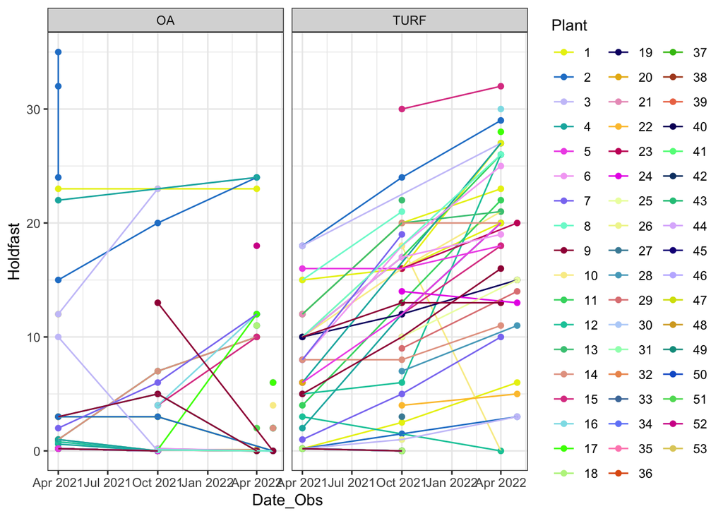

```r
# Monitoring dates are almost certainly incorrect
ggplot(Growth_Surv, aes(Date_Obs, Holdfast, group=paste(Plant, Site, Patch), colour=Plant)) +
  geom_point() + geom_line() + facet_wrap(~Management) +
  scale_colour_manual(values=randomcoloR::randomColor(53)) + theme_bw()
```